# Econometrics - Lecture 6

Categorical Predictors and Interaction Effects

Author

Logan Kelly Ph.D.

Published

January 28, 2025

## 1 Introduction

- Categorical Predictors (Dummy Variables)
- Interaction Effects

## 2 Key Concepts

- **Categorical Predictors (Dummy Variables)**
  - Representing qualitative variables quantitatively
  - Conversion of categorical data into binary indicators
- **Inclusion of Factors in Regression Models**
  - How R handles categorical data through factors
  - Automatic creation of dummy variables
- **Interpretation of Factor Levels**
  - Understanding coefficients for different categories
  - Reference category and its role in interpretation
- **Interaction Effects**
  - Concept of variables interacting to influence the dependent variable
  - Identifying and specifying interactions in regression models
- **Model Specification for Interactions**
  - Syntax in R for including interaction terms (`x1 * x2` or `x1:x2`)
- **Interpretation of Interaction Effects**
  - How the effect of one variable changes based on the level of another variable

## 3 Theoretical Discussion

### 3.1 Categorical Predictors (Dummy Variables)

- **Inclusion of Factors**
  - **Factors in R:**
    - R treats categorical variables as factors, which are internally represented as integers with associated labels
    - When included in a regression model, R automatically generates dummy variables for each level except the reference category

```r
# Sample dataset
data <- data.frame(
  Salary = c(50000, 60000, 55000, 65000, 70000, 62000, 58000, 72000),
  Education_ = factor(c('Bachelors', 'Masters', 'PhD', 'Bachelors', 'Masters', 'PhD', 'Bachelors', 'PhD')),
  Experience = c(5, 7, 10, 6, 8, 12, 4, 15),
  Gender_ = factor(c('Male', 'Female', 'Female', 'Male', 'Female', 'Male', 'Female', 'Male'))
)
```

The regression equation incorporating the dummy variable for gender can be written as:

$$\text{Salary} = \beta_0 + \beta_1 \times \text{Experience} + \beta_2 \times \text{Gender} + \epsilon$$

Where: - $\beta_0$ is the intercept (the expected salary for the reference category when all predictors are zero). - $\beta_1$ is the coefficient for `Experience`, representing the change in salary for each additional year of experience. - $\beta_2$ is the coefficient for `Gender`, representing the difference in salary between females and males. - $\epsilon$ is the error term.

Extensive form

$$y=\begin{cases}\beta_{0} +\beta_{1} x\ +\varepsilon&\rm{if\ Gender\ =\ 0}\\ (\beta_{0} +\beta_2 )+\beta_{1} \times x+\varepsilon&\rm{if\ Gender\ =\ 1}\end{cases}$$

- **Reference Category**
  - **Choice of Reference:**
    - The reference category is crucial as it serves as the baseline for comparison
    - Changing the reference category alters the interpretation of all other coefficients
  - **Impact on Interpretation:**
    - Selecting a meaningful reference category enhances the interpretability of the model
    - Typically, the most common or a neutral category is chosen as the reference

```r
model <- lm(Salary ~ Experience + Gender_, data = data)
summary(model)
```

```
Call:
lm(formula = Salary ~ Experience + Gender_, data = data)

Residuals:
      1       2       3       4       5       6       7       8
-7185.9  -468.7 -8844.7  6688.7  8406.0 -3063.4   907.4  3560.5

Coefficients:
            Estimate Std. Error t value Pr(>|t|)
(Intercept)  52591.2     6750.5   7.791 0.000558 ***
Experience    1125.4      782.1   1.439 0.209708
Gender_Male  -1032.1     5471.2  -0.189 0.857797
---
Signif. codes:  0 '***' 0.001 '**' 0.01 '*' 0.05 '.' 0.1 ' ' 1

Residual standard error: 7326 on 5 degrees of freedom
Multiple R-squared:  0.3011,    Adjusted R-squared:  0.02156
F-statistic: 1.077 on 2 and 5 DF,  p-value: 0.4083
```

### 3.2 Interaction Effects

- **When & Why**
  - **Theory Behind Interactions:**
    - Interaction effects occur when the effect of one predictor variable on the dependent variable depends on the level of another predictor
    - Captures the combined influence of two or more variables beyond their individual effects
  - **Use Cases:**
    - Situations where variables are believed to synergize or antagonize each other
    - Enhances model flexibility and accuracy in capturing complex relationships
- **Model Specification**
  - Syntax in R:
    - `Education * Experience` expands to `Education + Experience + Education:Experience`, including both main effects and their interaction
    - `Education:Experience` includes only the interaction term without the main effects
      $$y=\begin{cases}\beta_{0} +\beta_{1} x\ +\varepsilon&\text{if\ Education = Bachelors}\\ \beta_{0} +(\beta_{1} +\beta_{2} ) \times x+\varepsilon&\text{if\ Education = Masters}\\ \beta_{0} +(\beta_{1} +\beta_{3} ) \times x+\varepsilon&\rm{if\ Education = PhD}\end{cases}$$
  - Example:

```r
# Fit a model with interaction between Education and Experience
model_interaction <- lm(Salary ~ Education_ * Experience, data = data)

# Summary of the interaction model
summary(model_interaction)
```

```
Call:
lm(formula = Salary ~ Education_ * Experience, data = data)

Residuals:
         1          2          3          4          5          6          7
-7.667e+03  7.190e-12 -7.895e+01  3.833e+03 -6.907e-12  1.316e+02  3.833e+03
         8
-5.263e+01

Coefficients:
                             Estimate Std. Error t value Pr(>|t|)
(Intercept)                   40166.7    23788.8   1.688    0.233
Education_Masters            -50166.7    74490.3  -0.673    0.570
Education_PhD                -19035.1    33318.9  -0.571    0.625
Experience                     3500.0     4695.6   0.745    0.534
Education_Masters:Experience   6500.0    10499.6   0.619    0.599
Education_PhD:Experience       -105.3     5052.7  -0.021    0.985

Residual standard error: 6641 on 2 degrees of freedom
Multiple R-squared:  0.7703,    Adjusted R-squared:  0.1962
F-statistic: 1.342 on 5 and 2 DF,  p-value: 0.4792
```

**Visualize interaction effect**

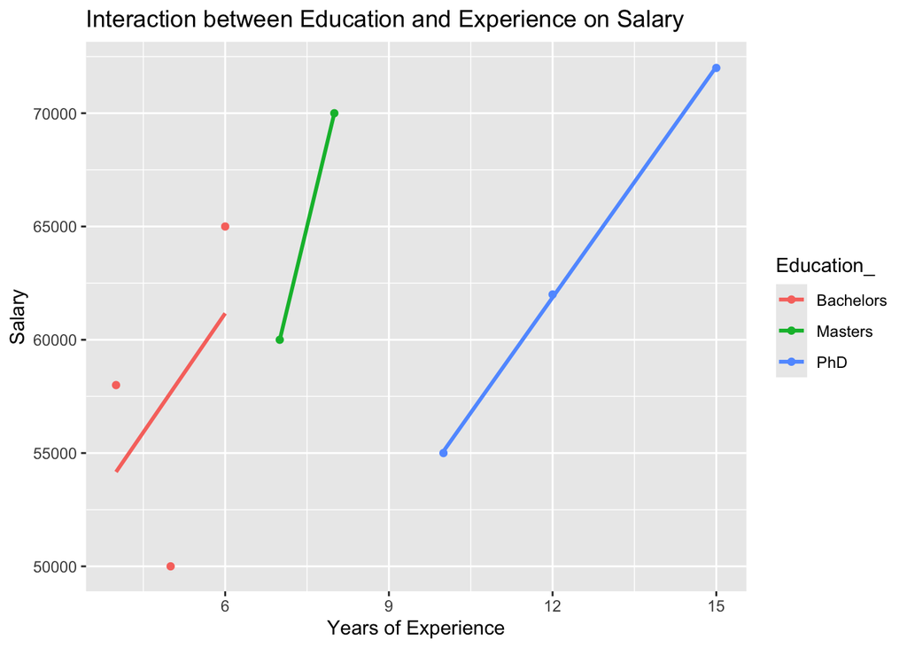

```r
pacman::p_load(ggplot2)
ggplot(data, aes(x = Experience, y = Salary, color = Education_)) +
  geom_point() +
  geom_smooth(method = "lm", se = FALSE) +
  labs(title = "Interaction between Education and Experience on Salary",
       x = "Years of Experience",
       y = "Salary")
```

- **Interpretation**
  - **Coefficient of Interaction Term:**
    - Represents how the relationship between one predictor and the dependent variable changes with the level of the other predictor
  - **Visualization:**
    - Interaction effects can be visualized using interaction plots to illustrate how slopes differ across levels of interacting variables
  - **Practical Implications:**
    - Provides deeper insights into the dynamics between variables, aiding in more informed decision-making

## 4 Case Study

- **Objective:**
  - Analyze the impact of the number of gears and weight on a car’s fuel efficiency (`mpg`), considering transmission type differences.
- **Dataset Overview:**
  - **Variables:**
    - **mpg:** Dependent variable (miles per gallon)
    - **gear:** Categorical predictor (number of forward gears: 3, 4, 5)
    - **wt:** Independent variable (weight of the car in 1000 lbs)
    - **am:** Categorical predictor (transmission type: 0 = automatic, 1 = manual)
- **Methodology:**
  - **Step 1:** Encode categorical variables (`gear` and `am`) as factors in R

```r
# Load the mtcars dataset
data <- mtcars

# Encode 'gear' and 'am' as factors
data$gear <- factor(data$gear, levels = c(3, 4, 5),
                    labels = c("3 Gears", "4 Gears", "5 Gears"))
data$am <- factor(data$am, levels = c(0, 1),
                 labels = c("Automatic", "Manual"))
```

- **Step 2:** Fit a multiple regression model including `gear` and `am` as categorical predictors

```r
# Fit multiple regression model with categorical predictors
model_main <- lm(mpg ~ gear + wt + am, data = data)
summary(model_main)
```

```
Call:
lm(formula = mpg ~ gear + wt + am, data = data)

Residuals:
    Min      1Q  Median      3Q     Max
-3.5798 -2.4056 -0.3692  1.8198  5.7713

Coefficients:
            Estimate Std. Error t value Pr(>|t|)
(Intercept)  35.0955     3.1862  11.015 1.72e-11 ***
gear4 Gears   2.0769     1.7343   1.198    0.242
gear5 Gears  -1.0615     2.3845  -0.445    0.660
wt           -4.8782     0.7945  -6.140 1.46e-06 ***
amManual      0.1883     1.9942   0.094    0.925
---
Signif. codes:  0 '***' 0.001 '**' 0.01 '*' 0.05 '.' 0.1 ' ' 1

Residual standard error: 2.968 on 27 degrees of freedom
Multiple R-squared:  0.7888,    Adjusted R-squared:  0.7575
F-statistic:  25.2 on 4 and 27 DF,  p-value: 8.931e-09
```

- **Step 3:** Introduce an interaction term between `gear` and `wt` to explore combined effects

```r
# Fit regression model with interaction between gear and wt
model_interaction <- lm(mpg ~ gear * wt + am, data = data)
summary(model_interaction)
```

```
Call:
lm(formula = mpg ~ gear * wt + am, data = data)

Residuals:
    Min      1Q  Median      3Q     Max
-2.9929 -1.7570  0.0941  0.9556  5.3892

Coefficients:
               Estimate Std. Error t value Pr(>|t|)
(Intercept)     28.3950     3.0053   9.448 9.95e-10 ***
gear4 Gears     26.1964     7.0213   3.731 0.000985 ***
gear5 Gears     19.4213     5.5105   3.524 0.001661 **
wt              -3.1569     0.7561  -4.175 0.000315 ***
amManual        -5.2535     2.4242  -2.167 0.039955 *
gear4 Gears:wt  -6.9918     2.0325  -3.440 0.002051 **
gear5 Gears:wt  -4.8895     1.6253  -3.008 0.005919 **
---
Signif. codes:  0 '***' 0.001 '**' 0.01 '*' 0.05 '.' 0.1 ' ' 1

Residual standard error: 2.356 on 25 degrees of freedom
Multiple R-squared:  0.8767,    Adjusted R-squared:  0.8471
F-statistic: 29.63 on 6 and 25 DF,  p-value: 3.325e-10
```

- **Step 4:** F-test on interaction term

```r
# Compare models
anova(model_main, model_interaction)
```

```
Analysis of Variance Table

Model 1: mpg ~ gear + wt + am
Model 2: mpg ~ gear * wt + am
  Res.Df    RSS Df Sum of Sq      F   Pr(>F)
1     27 237.87
2     25 138.82  2    99.047 8.9183 0.001193 **
---
Signif. codes:  0 '***' 0.001 '**' 0.01 '*' 0.05 '.' 0.1 ' ' 1
```

- **Step 5:** Visualize the results

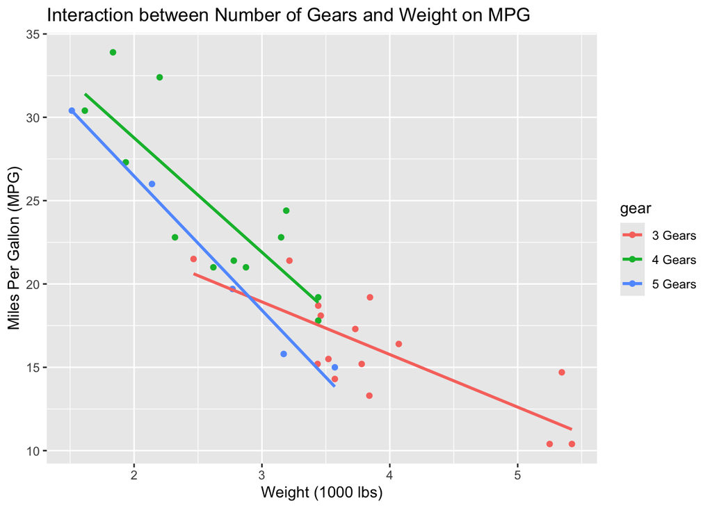

```r
# Visualize interaction effect
ggplot(data, aes(x = wt, y = mpg, color = gear)) +
  geom_point() +
  geom_smooth(method = "lm", se = FALSE) +
  labs(title = "Interaction between Number of Gears and Weight on MPG",
       x = "Weight (1000 lbs)",
       y = "Miles Per Gallon (MPG)")
```

- **Step 6:** Residual Diagnostics

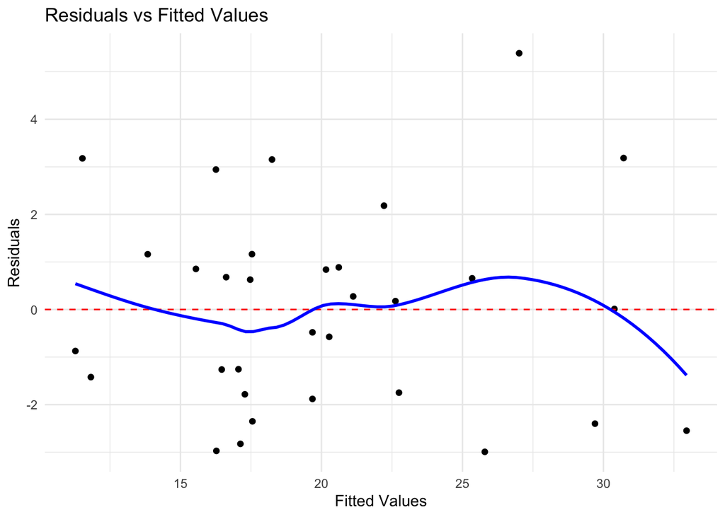

```r
# Residuals vs Fitted Values Plot
ggplot(model_interaction, aes(x = .fitted, y = .resid)) +
  geom_point() +
  geom_hline(yintercept = 0, linetype = "dashed", color = "red") +
  geom_smooth(method = "loess", se = FALSE, color = "blue") +
  labs(title = "Residuals vs Fitted Values",
       x = "Fitted Values",
       y = "Residuals") +
  theme_minimal()
```

## 5 Conclusion

- Takeaway 1: Properly encoding and interpreting categorical variables is essential for accurate regression analysis
- Takeaway 2: Interaction effects reveal deeper insights into the relationships between predictors
- Takeaway 3: Model specification in R is straightforward, allowing for complex model building with interactions